# Use Case Dynamic Pricing

## Data Science di Industri Retail

by Shellya Nur Atqiya

### What is Dynamic Pricing?

Dynamic pricing atau penetapan harga dinamis biasanya digunakan dalam industri perhotelan. Konsep dari dynamic pricing yaitu menggunakan data untuk mensegmentasikan pelanggan atau konsumen secara akurat, dan setiap kelompok pelanggan kemudian ditawari produk dengan harga berbeda antar tiap kelompoknya. Produk yang ditawarkan didasari pada data yang dihasilkan oleh Data Science dan faktor-faktor lainnya. Penetapan harga secara dinamis menjadikan harga fleksibel berdasarkan permintaan, penawaran dan persaingan harga. Harga bahkan dapat berubah dari pelanggan ke pelanggan berdasarkan kebiasaan pembelian mereka. Penetapan harga dinamis memungkinkan pemasok menjadi lebih fleksibel dan menyesuaikan harga agar lebih dipersonalisasi.

### How Dynamic Pricing Works?

Harga dinamis ditentukan oleh aturan atau yang memperhitungkan banyak variabel untuk menetapkan harga terbaik untuk produk tertentu untuk pelanggan itu pada waktu itu. Berikut beberapa variabel yang digunakan untuk membuat keputusan penetapan harga:

1. Supply (persediaan) :
- Stock levels
- Biaya saat ini
- Prediksi biaya di masa depan
1. Demand (permintaan):
- Viewers halaman produk
- Produk sesuai musim
1. Data Pelanggan :
- Data demografi seperti usia, jenis kelamin, lokasi, pendapatan
- Data perangkat, misal pengguna iPhone menghabiskan duit lebih banyak daripada pengguna Android
- Data perilaku seperti kebiasaan belanja pelanggan dan kesediaan pelanggan untuk mencari harga yang diinginkan
1. Persaingan Harga Sesama Penjual
2. dan lain sebagainya Setelah mengetahui hal-hal tersebut, mesin akan dilatih untuk dapat membangun model penetapan harga dinamis yang sukses.

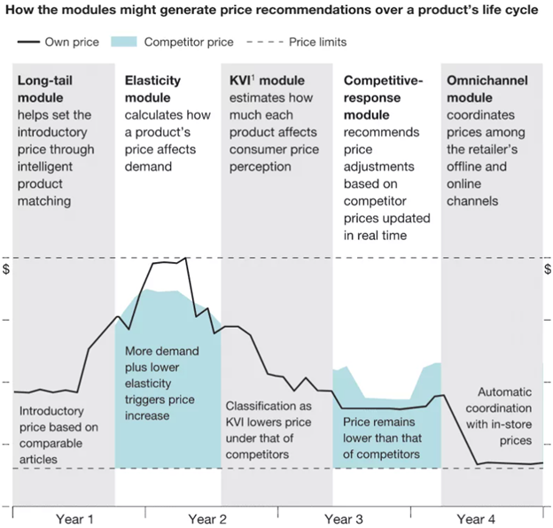

### The Benefits of Dynamic Pricing

Dynamic pricing memberikan profitabilitas terkuat. Kenaikan harga sebesar 1% akan menghasilkan peningkatan laba sebesar 10% untuk bisnis dengan margin keuntungan 10%. Sistem penetapan harga dinamis berbasis pembelajaran mesin memiliki keunggulan yang jelas jika dibandingkan dengan penetapan harga manual.

- Respon yang lebih cepat terhadap fluktuasi permintaan.
- Perubahan harga memperhitungkan lebih banyak faktor termasuk persepsi harga pelanggan, yang mengarah pada peningkatan penjualan atau keuntungan jangka panjang.
- Lebih banyak dampak positif pada pendapatan. Gambar di bawah menunjukkan berapa banyak nilai yang dihasilkan oleh penetapan harga dinamis dibandingkan dengan strategi penetapan harga lainnya.

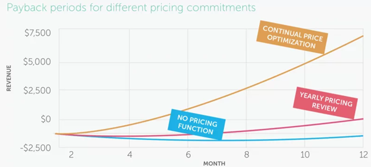

### Example

Salah satu perusahaan besar yang menggunakan use case dynamic pricing adalah AirBnB. Airbnb, Inc. adalah perusahaan Amerika yang mengoperasikan pasar online untuk penginapan, terutama homestay untuk persewaan liburan, dan aktivitas pariwisata. Ada beberapa faktor yang mempengaruhi harga sewa di AirBnB:

- Weekend dan Weekdays atau hari libur nasional: Seringkali destinasi wisata ramai pada akhir pekan atau liburan, terutama pada long weekends yang membuat harga sewa akan mencapai harga maksimal. Sebaliknya, harga pada weekday seringkali lebih murah karena permintaan yang rendah, meski begitu lebih baik harga diturunkan agar tetap terjadi transaksi daripada harga sama namun tidak ada transaksi.
- Diskon: Jika pemesanan dilakukan jauh-jauh hari sebelum tanggal menginap, AirBnB seringkali menawarkan diskon. Ada juga diskon jika konsumen menyewa dalam waktu lebih lama, misal biaya sewa perhari jika disewa selama 5 hari akan lebih murah dibanding hanya menyewa 1 hari.
- Penilaian: Jika suatu penginapan mendapat penilaian yang baik dari konsumen terdahulu, maka harga juga akan lebih mahal daripada penginapan yang mendapat penilaian kurang.

Sumber:

- https://research.aimultiple.com/dynamic-pricing/
- https://www.airdna.co/blog/perfecting-your-airbnb-pricing-strategy-why-dynamic-pricing-is-essential-to-optimizing-airbnb-prices